# Applied Math 10: Computing for Science and Engineering

### Statement of the problem

In this problem, you will solve the 2D diffusion equation for micro-organisms initially originating at $x=0, y=0$, with their concentration following the diffusive behavior of a Gaussian distribution (the initial distribution is a normalized Gaussian with $\sigma_x = 1, \sigma_y = 1$) with different values of the diffusion coefficient $D$ in each dimension (namely, $D_1$ in the x-dimension, and $D_2$ in the y-dimension).

The solution of the diffusion equation in 2D is a Gaussian in the $x$ and $y$ directions, with variance $\sigma_x$ and $\sigma_y$ that depend on the time and on the diffusion coefficients $D_1$ and $D_2$. Consider values $D_1$=4, and $D_2$=1 for the diffusion coefficients but choose your own values for the rest of the parameters.

(a) Plot the concentration every 50 time-steps (consider total number of time-steps nsteps=201), using contour plots.

(b) How many micro-organisms (in percentage terms, with respect to total) are present at a distance of $\sigma$ from the origin, in the $x-$ and in the $y-$ dimensions, after 200 timesteps?

(c) Simulate the diffusion process using the method of random walkers that we developed in Lecture 12. What parameters do you need to use (number of walkers, steps in the $x$ and $y$ directions, etc.) to get results close to those of the diffusion equation?

```
PART A
```

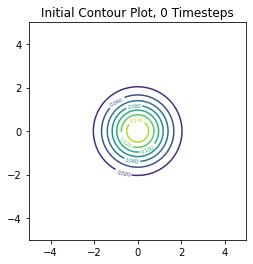

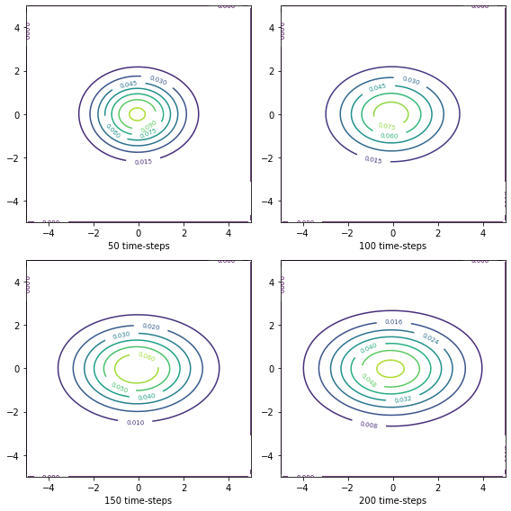

```
PART B

17.0 % of micro-organisms are within 1 standard deviation in the x and y direction after 200 timesteps

PART C
```

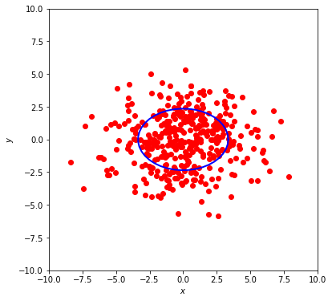

[output not shown]

```python
print("PART A")
#define 1 dimensional Gaussian
def gauss1D(x,x0,s):
    anorm=1.0/(np.sqrt(2.0*np.pi)*s)
    return anorm*np.exp(-(x-x0)**2/(2.0*(s**2)))

#define 2 dimensional Gaussian
def gauss2D(x,y,x0,y0,sx,sy):
    return gauss1D(x,x0,sx)*gauss1D(y,y0,sy)

#set values given in the problem statement
x0 = 0
y0 = 0
sx = 1.0 #sigma x
sy = 1.0 # sigma y

# Set up the parameters of the system
xmin = -5
xmax = 5
Nx = 100
x = np.linspace(xmin, xmax, Nx)
dx = x[1]-x[0]

ymin = -5
ymax = 5
Ny = 100
y = np.linspace(ymin, ymax, Ny)
dy = y[1]-y[0]

#meshgrid step
X, Y = np.meshgrid(x,y)

dt = 0.001 # define dt

u = np.zeros((Nx,Ny))

u0 = gauss2D(X,Y,x0,y0,sx,sy)

CP = plt.contour(X,Y,u0)
plt.clabel(CP, inline=1, fontsize=5)
plt.title("Initial Contour Plot, 0 Timesteps")
plt.axis('square')
plt.show()

def do2_timestep(u0, D1, D2, dx, dy, dt):

    Nx=len(u0)
    Ny=len(u0[0])

    u[0,0]=u0[0,0]
    u[0,Ny-1]=u0[0,Ny-1]
    u[Nx-1,0]=u0[Nx-1,0]
    u[Nx-1,Ny-1]=u0[Nx-1, Ny-1]

    for i in range(1, Nx-1):
        for j in range(1, Ny-1):

    # Propagate with forward-difference in time, central-difference in space

      #---------------------------------------------
            u[i,j] = u0[i,j] + D2 * dt * ((u0[i+1,j] - 2*u0[i,j] + u0[i-1,j]) / (dx * dx)) \
            + D1 * dt * ((u0[i,j+1] - 2*u0[i,j] + u0[i,j-1]) / (dy * dy))
      #---------------------------------------------

    return u


D1 = 4 # in the x direction
D2 = 1 # in the y direction

nsteps = 201 # from problem statement

# Output 4 figures at these timesteps
mfig = [50, 100, 150, 200]
fignum = 0
fig = plt.figure(figsize=(8,8))

for m in range(nsteps):
    u = do2_timestep(u0, D1, D2, dx, dy, dt)
    u0 = u

    if m in mfig:
        fignum += 1
        ax = fig.add_subplot(220 + fignum)
        CS = ax.contour(X,Y,u)
        ax.clabel(CS, inline=1, fontsize=7)
        ax.set_xlabel('{:.0f} time-steps'.format(m))

plt.tight_layout()
plt.show()

print('PART B')
print() # for formatting
# redefine parameters step
#set values given in the problem statement
x0 = 0
y0 = 0
sx = 1.0 #sigma x
sy = 1.0 # sigma y

# Set up the parameters of the system
xmin = -5
xmax = 5
Nx = 100
x = np.linspace(xmin, xmax, Nx)
dx = x[1]-x[0]

ymin = -5
ymax = 5
Ny = 100
y = np.linspace(ymin, ymax, Ny)
dy = y[1]-y[0]

#meshgrid step
X, Y = np.meshgrid(x,y)

dt = 0.001 # define dt

u = np.zeros((Nx,Ny))
# Redefine originial Gaussian
u0 = gauss2D(X,Y,x0,y0,sx,sy)

# get to 200 steps by going through a for loop of time steps
for m in range(nsteps):
    u = do2_timestep(u0, D1, D2, dx, dy, dt)
    u0 = u
# We want to look at a circle with a center at the origin and radius of size 1
insidecircle = 0 # this is to keep track of values INSIDE my circle
initial = np.sum(u) # this is the initial amount of microorganisms
for q in range(100): # for loop to go through x points, I have 100 of them
    for r in range(100): # for loop to go through y points, I have 100 of them
        origin_distance = np.sqrt((r-50)**2+(q-50)**2) # calculates distance point is from origin (Nx/2,Ny/2)
        if origin_distance < 10: #radius of 1 for 100 points on axis of 10 would actually be 10
            insidecircle += u[q,r] # add the function value at that point if it is inside the circle
percentage = (insidecircle/initial)*100 # to get percentage that are inside the circle
print(np.round(percentage,1),"% of micro-organisms are within 1 standard deviation in the x and y direction after 200 timesteps")
print() # for formatting
# I thought about using the equations for sigma as a function of time from lecture 12
# but I was getting a sigma y less than 1 which didnt make sense, the standard deviation should be getting larger not smaller
print('PART C')
# Initialize parameters
Deltat= 100              # total time duration

Nwalk= 400                # Number of walkers

deltx = 1            # step in x direction
delty = 0.7            # step in y direction
#
#  from the defined parameters obtain steps and range
#
delt=np.sqrt(deltx**2+delty**2)                # distance for each step
DRX=np.sqrt(Deltat*deltx)   # range of walkers that can be reached during this time
DRY=np.sqrt(Deltat*delty)   # range of walkers that can be reached during this time
DR=max(DRX,DRY)
#
#  here we define an ELLIPSE of size equal to the average square displacement
#  to be calculated during the simulation
#
Npidiv=40
theta=np.linspace(0,2*np.pi,Npidiv)
xel=np.zeros(Npidiv)
yel=np.zeros(Npidiv)
#
# initialize arrays
#
xpos=np.zeros(Nwalk)
ypos=np.zeros(Nwalk)
rdist=np.zeros(Deltat)
times=np.zeros(Deltat)
xav=np.zeros(Deltat)
yav=np.zeros(Deltat)
x2av=np.zeros(Deltat)
y2av=np.zeros(Deltat)
#
# run the simulation for total time Deltat
#

for t in range (Deltat):
    times[t]=t
    xpos=xpos+deltx*(np.random.rand(Nwalk)-0.5)
    ypos=ypos+delty*(np.random.rand(Nwalk)-0.5)
    xav[t]=np.mean(xpos)
    yav[t]=np.mean(ypos)
    x2av[t]=np.mean(xpos**2)
    y2av[t]=np.mean(ypos**2)
    rdist[t]=(np.sum(xpos**2)+np.sum(ypos**2))/Nwalk
    xel=deltx*np.sqrt(rdist[t-1])*np.cos(theta)
    yel=delty*np.sqrt(rdist[t-1])*np.sin(theta)
#
#  plot the actual positions of walkers on the 2D plane
#
fig=plt.figure(figsize=(6,6))
plt.plot(xpos,ypos,'ro',lw=2)
plt.plot(xel,yel,'b-',lw=2)
plt.xlabel('$x$')
plt.ylabel('$y$')
plt.xlim(-DR,DR)
plt.ylim(-DR,DR)
plt.show()
print("To get results close to those of the diffusion equation, I used 400 walkers, a step of 1 the X direction and 0.7 in the Y direction. As you can see from the ellipse in blue, it resembles the shape of my graph above after 200 timesteps, with the Gaussian flattened out and widened out. I used 100 timesteps in my scenario here, that way the size of my blue ellipse closely resembles the size of the outer most contour line in the graph. Of course, like we did in lecture 12, these parameters can be adjusted, but I found these parameters to closely represent the shape that I was looking for!")
```

## Problem 4: Waves from dripping source

### Preamble

In this problem, you will construct a visualization of waves in two dimensions, like those on the surface of liquid, generated by dripping of droplets at a constant rate.

The expression for a circular wave in water is given by

$$ \psi(r,t) = A \cos(k r - \omega t)$$

where $\psi(r,t)$ is the value of the wave at position $r$ and time $t$, $A$ is the amplitude, and $k, \omega$ are the spatial and temporal period of the wave, related by $v = \omega/k$, with $v$ the velocity of the wave.

In the above expression, the distance $r$ from the the origin is given by $$ r = \sqrt{x^2+y^2}$$ where $x, y$ are the points on the plane where we measure the wave.

For this problem we will use $k = 0.5$ and $\omega = 5$.

### Statement of the problem

a) For the values of $x,y$ within a square of side $L$, plot the waves generated by a single dripping source at the center of the square, using the expression for the solution $\psi(r,t)$ given above. Use both a contour plot and a three-dimensional perspective plot (with the routines we provided in Lecture 8). Make sure you use a value of $L$ and a value of $A$ that produce waves which can be easily visualized. Plot the waves at 3 different moments in time (of your choice), for all the values of the $(x,y)$ grid.

b) Within the same square on the $(x,y)$ plane, use two different sources for the waves (from two synchronized dripping sources), one at the position $p_1 = (L/4, L/4)$ and the other at the position $p_2 = (3L/4, 3L/4)$.

In this case the total wave is a superposition of the waves from the two individual sources, that is:

$$ \psi(r,t) = A \left [ \cos(k r_1 - \omega t) + \cos(k r_2 - \omega t)\right ] $$

where $$r_1 = \sqrt{(x-p_{1x})^2+(y-p_{1y})^2}, r_2 = \sqrt{(x-p_{2x})^2+(y-p_{2y})^2}$$

Plot the new waves that come from both sources, for the same moments in time as in part (a) and compare the wave patterns.

c) If the second source starts dripping out of sync, with time lag of $\delta t$, with the first one, how can you modify you code to capture the waves produced in this situation? Choose a difference in the time $\delta t$ and plot again the waves from the two sources as in part (b). Are there any interesting effects as $\delta t$ is changed?

```
PART A
```

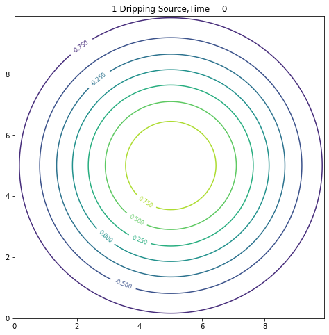

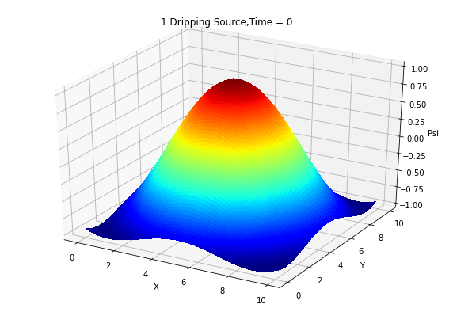

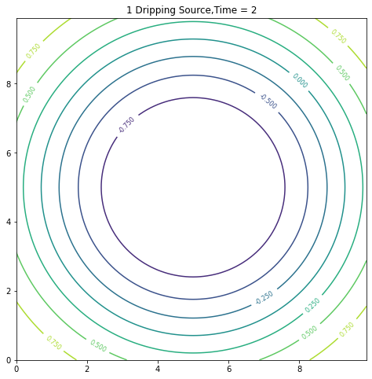

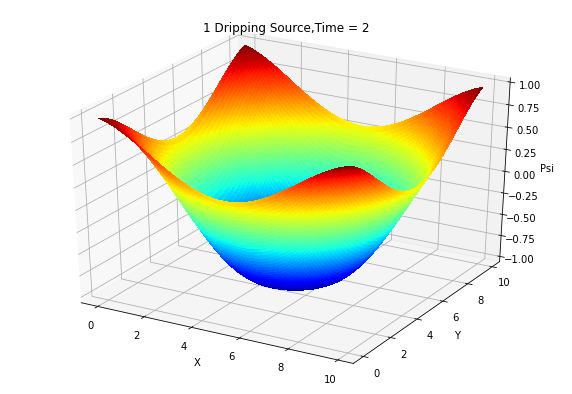

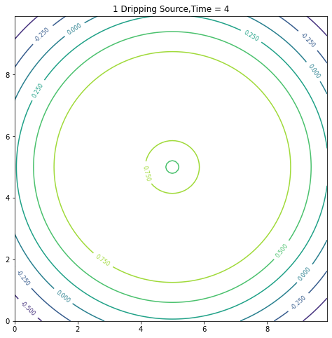

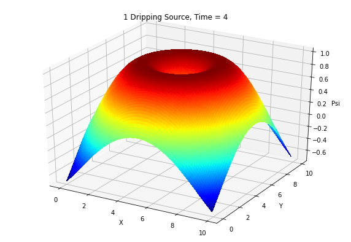

```
PART B
```

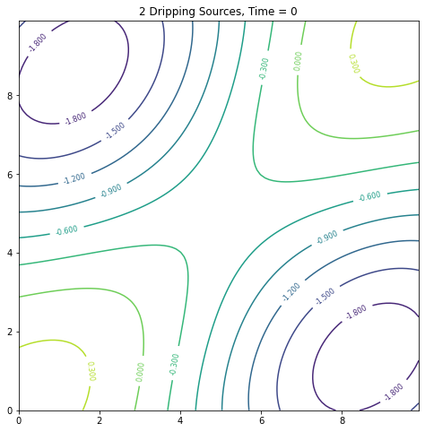

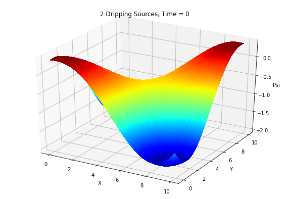

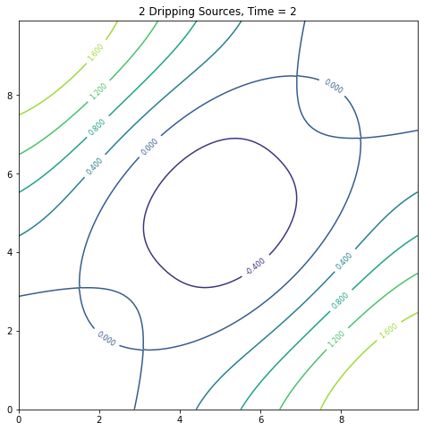

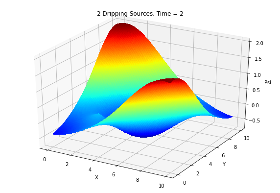

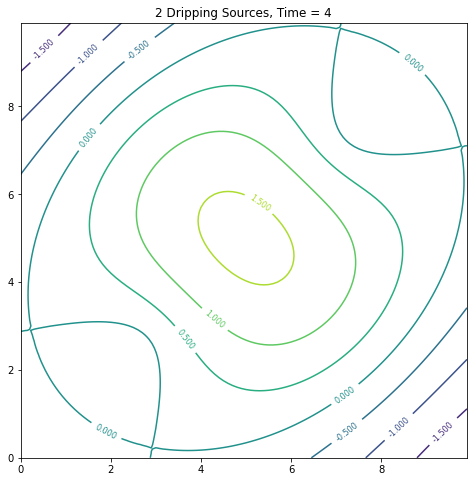

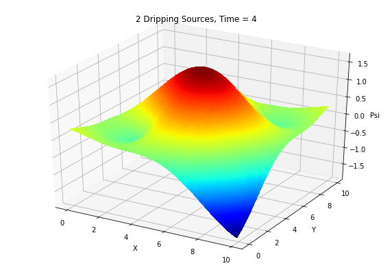

```
The wave patterns with only 1 dripping source are not too complex and resemble paraboloids, but with 2 dripping sources, the wave patterns are much more complex, bearing little resemblence to any regular quadric surface from multivariable calculus

PART C
```

[2 more figures not shown]

[output not shown]

```python
k = 0.5 # from problem statement
omega = 5 #from problem statement
A = 1 # defining my amplitude as 1 for simplicity
print('PART A')
L = 10 # This is the length of my square, so center is at (5,5)

xmin = 0 # define x interval
xmax = L
dx = 0.1
x = np.arange(xmin,xmax,dx)

ymin = 0 # define y interval
ymax = L
dy = 0.1
y = np.arange(ymin,ymax,dy)

t = 0 # first look at when time = 0

def psi(x,y): # define function psi
    return A*np.cos(k * np.sqrt((x-L/2)**2+(y-L/2)**2) - omega*t) # replacing the r in terms of x and y

X, Y = np.meshgrid(x,y) # meshgrid step
PSIplot = psi(X,Y) # get function vlaues
fig, ax = plt.subplots(figsize=(8,8)) # plotting routine
CS = ax.contour(X,Y,PSIplot)
ax.clabel(CS, inline=1, fontsize=8)
ax.set_title("1 Dripping Source,Time = 0")
plt.show()
Nx=np.size(x)
Ny=np.size(y)
psimax=np.max(PSIplot)
psimin=np.min(PSIplot)
fig = plt.figure(figsize=(10,7))
ax = fig.add_subplot(111, projection='3d')
ax.plot_surface(X, Y, PSIplot, rstride=1, cstride=1, cmap=cm.jet, linewidth=0,
    antialiased=False)
ax.set_zlim(psimin*1.02,psimax*1.02)
ax.set_xlabel('X')
ax.set_ylabel('Y')
ax.set_zlabel('Psi')
ax.set_title("1 Dripping Source,Time = 0")
plt.show()

# now lets look at when time = 2
t = 2
X, Y = np.meshgrid(x,y)
PSIplot = psi(X,Y) # get new function values using the new t
fig, ax = plt.subplots(figsize=(8,8)) # plotting routine
CS = ax.contour(X,Y,PSIplot)
ax.clabel(CS, inline=1, fontsize=8)
ax.set_title("1 Dripping Source,Time = 2")
plt.show()
Nx=np.size(x)
Ny=np.size(y)
psimax=np.max(PSIplot)
psimin=np.min(PSIplot)
fig = plt.figure(figsize=(10,7))
ax = fig.add_subplot(111, projection='3d')
ax.plot_surface(X, Y, PSIplot, rstride=1, cstride=1, cmap=cm.jet, linewidth=0,
    antialiased=False)
ax.set_zlim(psimin*1.02,psimax*1.02)
ax.set_xlabel('X')
ax.set_ylabel('Y')
ax.set_zlabel('Psi')
ax.set_title("1 Dripping Source,Time = 2")
plt.show()

# Now lets look at when time = 4
t = 4
X, Y = np.meshgrid(x,y)
PSIplot = psi(X,Y) # get new function values with new t
fig, ax = plt.subplots(figsize=(8,8)) # plotting routine
CS = ax.contour(X,Y,PSIplot)
ax.clabel(CS, inline=1, fontsize=8)
ax.set_title("1 Dripping Source,Time = 4")
plt.show()
Nx=np.size(x)
Ny=np.size(y)
psimax=np.max(PSIplot)
psimin=np.min(PSIplot)
fig = plt.figure(figsize=(10,7))
ax = fig.add_subplot(111, projection='3d')
ax.plot_surface(X, Y, PSIplot, rstride=1, cstride=1, cmap=cm.jet, linewidth=0,
    antialiased=False)
ax.set_zlim(psimin*1.02,psimax*1.02)
ax.set_xlabel('X')
ax.set_ylabel('Y')
ax.set_zlabel('Psi')
ax.set_title("1 Dripping Source, Time = 4")
plt.show()

print('PART B')
def psi2(x,y): # define new function psi2 since there are 2 dripping sources
    return A*(np.cos(k*np.sqrt((x-p1)**2+(y-p1)**2)-omega*t)+np.cos(k*np.sqrt((x-p2)**2+(y-p2)**2)-omega*t))
p1 = L/4 # p1x and p1y are the same values so just need 1 p1, for me this is at (2.5,2.5)
p2 = 3*L/4 # p2x and p2y are the same values so just need 1 p2, for me this is at (7.5, 7.5)
t = 0 # first look at when t = 0

PSIplot = psi2(X,Y) # use new function
fig, ax = plt.subplots(figsize=(8,8)) # plotting routine
CS = ax.contour(X,Y,PSIplot)
ax.clabel(CS, inline=1, fontsize=8)
ax.set_title("2 Dripping Sources, Time = 0")
plt.show()
Nx=np.size(x)
Ny=np.size(y)
psimax=np.max(PSIplot)
psimin=np.min(PSIplot)
fig = plt.figure(figsize=(10,7))
ax = fig.add_subplot(111, projection='3d')
ax.plot_surface(X, Y, PSIplot, rstride=1, cstride=1, cmap=cm.jet, linewidth=0,
    antialiased=False)
ax.set_zlim(psimin*1.02,psimax*1.02)
ax.set_xlabel('X')
ax.set_ylabel('Y')
ax.set_zlabel('Psi')
ax.set_title("2 Dripping Sources, Time = 0")
plt.show()

t = 2 # then look at when t = 2
PSIplot = psi2(X,Y) # get new function values at new time
fig, ax = plt.subplots(figsize=(8,8)) # plotting routine
CS = ax.contour(X,Y,PSIplot)
ax.clabel(CS, inline=1, fontsize=8)
ax.set_title("2 Dripping Sources, Time = 2")
plt.show()
Nx=np.size(x)
Ny=np.size(y)
psimax=np.max(PSIplot)
psimin=np.min(PSIplot)
fig = plt.figure(figsize=(10,7))
ax = fig.add_subplot(111, projection='3d')
ax.plot_surface(X, Y, PSIplot, rstride=1, cstride=1, cmap=cm.jet, linewidth=0,
    antialiased=False)
ax.set_zlim(psimin*1.02,psimax*1.02)
ax.set_xlabel('X')
ax.set_ylabel('Y')
ax.set_zlabel('Psi')
ax.set_title("2 Dripping Sources, Time = 2")
plt.show()

t = 4 # then look at when t = 4
PSIplot = psi2(X,Y) # get new function values with new time
fig, ax = plt.subplots(figsize=(8,8)) # plotting routine
CS = ax.contour(X,Y,PSIplot)
ax.clabel(CS, inline=1, fontsize=8)
ax.set_title("2 Dripping Sources, Time = 4")
plt.show()
Nx=np.size(x)
Ny=np.size(y)
psimax=np.max(PSIplot)
psimin=np.min(PSIplot)
fig = plt.figure(figsize=(10,7))
ax = fig.add_subplot(111, projection='3d')
ax.plot_surface(X, Y, PSIplot, rstride=1, cstride=1, cmap=cm.jet, linewidth=0,
    antialiased=False)
ax.set_zlim(psimin*1.02,psimax*1.02)
ax.set_xlabel('X')
ax.set_ylabel('Y')
ax.set_zlabel('Psi')
ax.set_title("2 Dripping Sources, Time = 4")
plt.show()
print()
print("The wave patterns with only 1 dripping source are not too complex and resemble paraboloids, but with 2 dripping sources, the wave patterns are much more complex, bearing little resemblence to any regular quadric surface from multivariable calculus")
print()
print('PART C')
t0 = 0 # originial time, source at (2.5,2.5) is dripping at t = 0
def ontime(x,y): # define function ontime
    return A*np.cos(k * np.sqrt((x-L/4)**2+(y-L/4)**2) - omega*t0)
t = t0 + 3 # out of sync, source at (7.5,7.5) is dripping at t = 3
def lag(x,y): # define function lag that uses different values of t
    return A*np.cos(k * np.sqrt((x-3*L/4)**2+(y-3*L/4)**2) - omega*t)
PSIplot = ontime(X,Y)+lag(X,Y) # add the two plots together! Like we did in the midterm with the wells
fig, ax = plt.subplots(figsize=(8,8)) # plotting routine
CS = ax.contour(X,Y,PSIplot)
ax.clabel(CS, inline=1, fontsize=8)
ax.set_title("2 Sources w/ Timelag of 3")
plt.show()
Nx=np.size(x)
Ny=np.size(y)
psimax=np.max(PSIplot)
psimin=np.min(PSIplot)
fig = plt.figure(figsize=(10,7))
ax = fig.add_subplot(111, projection='3d')
ax.plot_surface(X, Y, PSIplot, rstride=1, cstride=1, cmap=cm.jet, linewidth=0,
    antialiased=False)
ax.set_zlim(psimin*1.02,psimax*1.02)
ax.set_xlabel('X')
ax.set_ylabel('Y')
ax.set_zlabel('Psi')
ax.set_title("2 Sources w/ Timelag of 3")
plt.show()
print("Yes, something interesting does happen as the time lag changes. If you set the time lag equal to omega, which in this case is 5, the plots look the same as if the drops were happening at the same time. This is like being in phase in physics, and when the time lag is between 0 and omega(5), it is like being out of phase!")
```